# Machine Learning Project

### MODEL SIMULATIONS

Use 10-fold cross validation with 75% training sample size to train each model and with a 25% testing sample size to determine its expected out-of-sample error rate. Used preProcess=“pca” however it decreased accuracy slightly while it increased processing time by a few minutes which didn’t make for a good trade-off.

MODEL ONE: SUPPORT VECTOR MACHINE

```r
set.seed(32323)# set initial seed
# Use default values for the model
modfit1<-svm(classe~., data=train, trControl=trainControl(method="cv", number=10, p=0.75, allowParallel=T))
# Save results for quick retrieval
save(modfit1, file="modfit1.RData")
load("modfit1.RData")
# Predict using test set
pred1<-predict(modfit1, test)
# Show accuracy matrix
confusionMatrix(pred1, test$classe)
```

```
## Confusion Matrix and Statistics
##
##           Reference
## Prediction    A    B    C    D    E
##          A 1390   69    1    1    2
##          B    1  851   30    0    7
##          C    4   24  817   85   18
##          D    0    1    7  718   20
##          E    0    4    0    0  854
##
## Overall Statistics
##
##                Accuracy : 0.9441
##                  95% CI : (0.9373, 0.9504)
##     No Information Rate : 0.2845
##     P-Value [Acc > NIR] : < 2.2e-16
##
##                   Kappa : 0.9292
##  Mcnemar's Test P-Value : < 2.2e-16
##
## Statistics by Class:
##
##                      Class: A Class: B Class: C Class: D Class: E
## Sensitivity            0.9964   0.8967   0.9556   0.8930   0.9478
## Specificity            0.9792   0.9904   0.9676   0.9932   0.9990
## Pos Pred Value         0.9501   0.9573   0.8618   0.9625   0.9953
## Neg Pred Value         0.9985   0.9756   0.9904   0.9793   0.9884
## Prevalence             0.2845   0.1935   0.1743   0.1639   0.1837
## Detection Rate         0.2834   0.1735   0.1666   0.1464   0.1741
## Detection Prevalence   0.2983   0.1813   0.1933   0.1521   0.1750
## Balanced Accuracy      0.9878   0.9436   0.9616   0.9431   0.9734
```

```r
# Post results
# modfit1
ac1<-round(confusionMatrix(pred1, test$classe)$overall[1], 5)
paste("Accuracy for SVM is:", ac1)
```

```
## [1] "Accuracy for SVM is: 0.94413"
```

```r
paste("Out of Sample error rate is:", 1-ac1)
```

```
## [1] "Out of Sample error rate is: 0.05587"
```

MODEL TWO: CART CLASSIFICATION TREE

```r
set.seed(32323)# set initial seed
# Use default values for the model
modfit2<-train(classe~., method="rpart", data=train, trControl=trainControl(method="cv", number=10, p=0.75, allowParallel=T))
# Save results for quick retrieval
save(modfit2, file="modfit2.RData")
load("modfit2.RData")
# Predict using test set
pred2<-predict(modfit2, test)
# Show accuracy matrix
confusionMatrix(pred2, test$classe)
```

```
## Confusion Matrix and Statistics
##
##           Reference
## Prediction    A    B    C    D    E
##          A 1253  380  390  356  130
##          B   31  328   37  141  137
##          C  108  241  428  307  224
##          D    0    0    0    0    0
##          E    3    0    0    0  410
##
## Overall Statistics
##
##                Accuracy : 0.4933
##                  95% CI : (0.4792, 0.5074)
##     No Information Rate : 0.2845
##     P-Value [Acc > NIR] : < 2.2e-16
##
##                   Kappa : 0.3384
##  Mcnemar's Test P-Value : NA
##
## Statistics by Class:
##
##                      Class: A Class: B Class: C Class: D Class: E
## Sensitivity            0.8982  0.34563  0.50058   0.0000  0.45505
## Specificity            0.6421  0.91252  0.78266   1.0000  0.99925
## Pos Pred Value         0.4994  0.48665  0.32722      NaN  0.99274
## Neg Pred Value         0.9407  0.85319  0.88126   0.8361  0.89067
## Prevalence             0.2845  0.19352  0.17435   0.1639  0.18373
## Detection Rate         0.2555  0.06688  0.08728   0.0000  0.08361
## Detection Prevalence   0.5116  0.13744  0.26672   0.0000  0.08422
## Balanced Accuracy      0.7701  0.62907  0.64162   0.5000  0.72715
```

```r
# Post results
# modfit2
ac2<-round(confusionMatrix(pred2, test$classe)$overall[1], 5)
paste("Accuracy for Classification Tree is:", ac2)
```

```
## [1] "Accuracy for Classification Tree is: 0.49327"
```

```r
paste("Out of Sample error rate is:", 1-ac2)
```

```
## [1] "Out of Sample error rate is: 0.50673"
```

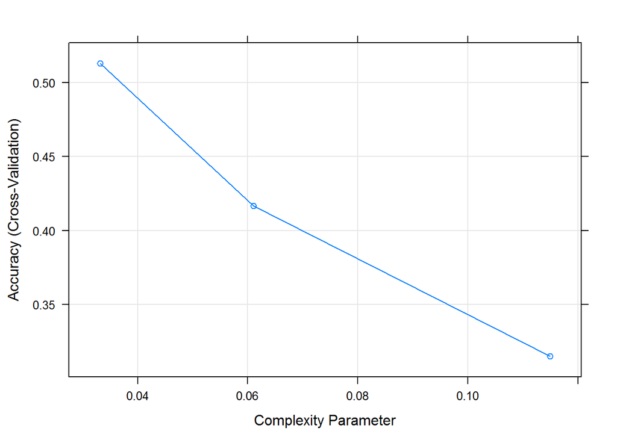

```r
plot(modfit2)
```

MODEL THREE: RANDOM FOREST

```r
set.seed(32323)# set initial seed
# Use default values for the model
modfit3<-randomForest(classe~., train, importance=T, trControl=trainControl(method="cv", number=10, p=0.75, allowParallel=T))
# Save results for quick retrieval
save(modfit3, file="modfit3.RData")
load("modfit3.RData")
# Predict using test set
pred3 <- predict(modfit3, newdata = test)
# Show accuracy matrix
confusionMatrix(pred3, test$classe)
```

```
## Confusion Matrix and Statistics
##
##           Reference
## Prediction    A    B    C    D    E
##          A 1392    0    0    0    0
##          B    2  948    4    0    0
##          C    0    1  851    9    2
##          D    1    0    0  795    2
##          E    0    0    0    0  897
##
## Overall Statistics
##
##                Accuracy : 0.9957
##                  95% CI : (0.9935, 0.9973)
##     No Information Rate : 0.2845
##     P-Value [Acc > NIR] : < 2.2e-16
##
##                   Kappa : 0.9946
##  Mcnemar's Test P-Value : NA
##
## Statistics by Class:
##
##                      Class: A Class: B Class: C Class: D Class: E
## Sensitivity            0.9978   0.9989   0.9953   0.9888   0.9956
## Specificity            1.0000   0.9985   0.9970   0.9993   1.0000
## Pos Pred Value         1.0000   0.9937   0.9861   0.9962   1.0000
## Neg Pred Value         0.9991   0.9997   0.9990   0.9978   0.9990
## Prevalence             0.2845   0.1935   0.1743   0.1639   0.1837
## Detection Rate         0.2838   0.1933   0.1735   0.1621   0.1829
## Detection Prevalence   0.2838   0.1945   0.1760   0.1627   0.1829
## Balanced Accuracy      0.9989   0.9987   0.9962   0.9940   0.9978
```

```r
# Post results
ac3<-round(confusionMatrix(pred3, test$classe)$overall[1], 5)
paste("Accuracy for Random Forest is:", ac3)
```

```
## [1] "Accuracy for Random Forest is: 0.99572"
```

```r
paste("Out of Sample error rate is:", round(1-ac3,5))
```

```
## [1] "Out of Sample error rate is: 0.00428"
```

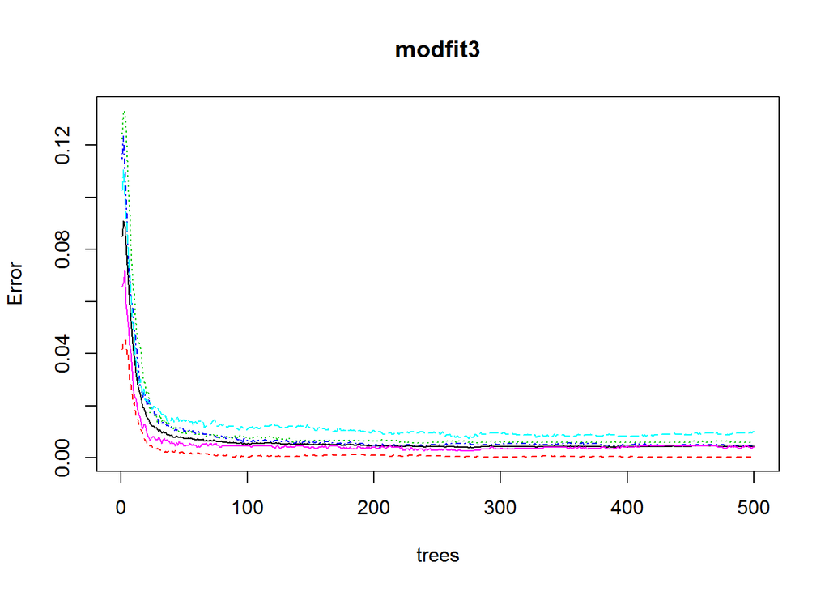

```r
plot(modfit3)
```

MODEL FOUR: BAGGING

```r
set.seed(32323)# set initial seed
# Use default values for the model
modfit4<-train(classe~., method="treebag", data=train, trControl=trainControl(method="cv", number=10), allowParallel=T)
# Save results for quick retrieval
save(modfit4, file="modfit4.RData")
load("modfit4.RData")
# Predict using test set
pred4<-predict(modfit4, test)
# Show accuracy matrix
confusionMatrix(pred4, test$classe)
```

```
## Confusion Matrix and Statistics
##
##           Reference
## Prediction    A    B    C    D    E
##          A 1385   15    2    1    1
##          B    8  920    6    1    3
##          C    1   11  840   11    4
##          D    1    3    7  791    4
##          E    0    0    0    0  889
##
## Overall Statistics
##
##                Accuracy : 0.9839
##                  95% CI : (0.98, 0.9872)
##     No Information Rate : 0.2845
##     P-Value [Acc > NIR] : < 2e-16
##
##                   Kappa : 0.9796
##  Mcnemar's Test P-Value : 0.05802
##
## Statistics by Class:
##
##                      Class: A Class: B Class: C Class: D Class: E
## Sensitivity            0.9928   0.9694   0.9825   0.9838   0.9867
## Specificity            0.9946   0.9954   0.9933   0.9963   1.0000
## Pos Pred Value         0.9865   0.9808   0.9689   0.9814   1.0000
## Neg Pred Value         0.9971   0.9927   0.9963   0.9968   0.9970
## Prevalence             0.2845   0.1935   0.1743   0.1639   0.1837
## Detection Rate         0.2824   0.1876   0.1713   0.1613   0.1813
## Detection Prevalence   0.2863   0.1913   0.1768   0.1644   0.1813
## Balanced Accuracy      0.9937   0.9824   0.9879   0.9901   0.9933
```

```r
# Post results
# modfit4
ac4<-round(confusionMatrix(pred4, test$classe)$overall[1], 5)
paste("Accuracy for Bagging is:", ac4)
```

```
## [1] "Accuracy for Bagging is: 0.98389"
```

```r
paste("Out of Sample error rate is:", 1-ac4)
```

```
## [1] "Out of Sample error rate is: 0.01611"
```

### CONCLUSIONS

Of the four models simulated, Random Forest has the best accuracy and therefore lowest out-of-sample error rate.

```r
# Summarize results of modeling
accuracy<-data.frame(SVM=ac1, ClassTree=ac2, RF=ac3, Bag=ac4)
err<-data.frame(SVM=1-ac1, ClassTree=1-ac2, RF=1-ac3, Bag=1-ac4); rownames(err)<-"OOS Error"
# Print results
accuracy
```

```
##              SVM ClassTree      RF     Bag
## Accuracy 0.94413   0.49327 0.99572 0.98389
```

```r
err
```

```
##               SVM ClassTree      RF     Bag
## OOS Error 0.05587   0.50673 0.00428 0.01611
```

```r
bestmod<-modfit3
bestmod
```

```
##
## Call:
##  randomForest(formula = classe ~ ., data = train, importance = T,      trControl = trainControl(method = "cv", number = 10, p = 0.75,          allowParallel = T))
##                Type of random forest: classification
##                      Number of trees: 500
## No. of variables tried at each split: 7
##
##         OOB estimate of  error rate: 0.44%
## Confusion matrix:
##      A    B    C    D    E  class.error
## A 4184    1    0    0    0 0.0002389486
## B   13 2831    4    0    0 0.0059691011
## C    0   12 2555    0    0 0.0046747176
## D    0    0   23 2388    1 0.0099502488
## E    0    0    3    8 2695 0.0040650407
```

```r
paste("The resulting Random Forest model has the following parameters: (1) Type of random forest:", modfit3$type, "(2) Number of trees:", modfit3$ntree, "(3) No. of variables tried at each split:", modfit3$mtry)
```

```
## [1] "The resulting Random Forest model has the following parameters: (1) Type of random forest: classification (2) Number of trees: 500 (3) No. of variables tried at each split: 7"
```

### APPLYING BEST MODEL ON VALIDATION SET

```r
# Predicting on validation set
predvalid <- predict(bestmod, newdata = valid)
predvalid
```

```
##  1  2  3  4  5  6  7  8  9 10 11 12 13 14 15 16 17 18 19 20
##  B  A  B  A  A  E  D  B  A  A  B  C  B  A  E  E  A  B  B  B
## Levels: A B C D E
```